# Prediction Assignment Writeup

Practical Machine Learning Course Project

Aleksandr Smetanin

30 April 2016

## Introduction

This work is dedicated to qualitative activity recognition. While many articles are concerned with recognising *which* activity is performed, this research is concerned with recognising *how well* it is performed.

Six participants were asked to perform one set of 10 repetitions of the Unilateral Dumbbell Biceps Curl in five different fashions: exactly according to the specification (Class A), throwing the elbows to the front (Class B), lifting the dumbbell only halfway (Class C), lowering the dumbbell only halfway (Class D) and throwing the hips to the front (Class E). Class A corresponds to the correct execution of the exercise, while the other 4 classes correspond to common mistakes. The data was recorded by four 9 degrees of freedom Razor inertial measurement units (IMU), which provide three-axes acceleration, gyroscope and magnetometer data at a joint sampling rate of 45 Hz. The sensors was mounted in the sportsmens’ glove, armband, lumbar belt and dumbbell [1].

The goal of the work is to predict Class of exercises registered by IMUs.

The data for this project come from this source: http://groupware.les.inf.puc-rio.br/har. Two data sets were provided: one for [training](https://d396qusza40orc.cloudfront.net/predmachlearn/pml-training.csv) and one for [test](https://d396qusza40orc.cloudfront.net/predmachlearn/pml-testing.csv) purposes.

## Data processing

### Loading data

The data is supplied in two separate data set. We read training data into *df* data frame and testing data into *mainTest* data frame.

```r
# read data
df <- read.csv("pml-training.csv")
mainTest <- read.csv("pml-testing.csv")
table(df$classe)
```

```
##
##    A    B    C    D    E
## 5580 3797 3422 3216 3607
```

The test set will be used only for prediction purpose. There are only 20 cases to predict Class. The training set will be used for all other activities. It has 19622 observations. Outcome variable is *classe* that is factor with 5 levels.

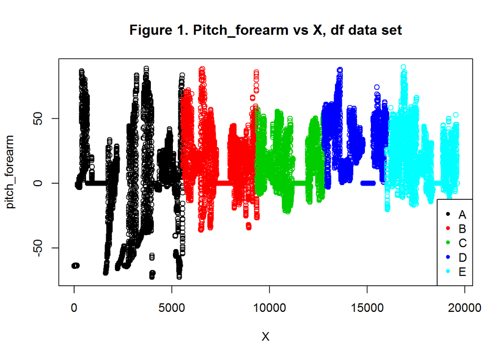

Variable *X* is a row number. A plot of any variable against *X* shows nice classification: first rows belongs to Class A, next rows goes to Class B, etc. For example, fugire 1 shows dependence of *pitch_forearm* against row number. This variable *X* looks like very strong predictor which indeed will cause many classification errors if someone just rearranges our data. Obviuosly, row number can not be treated as a predictor.

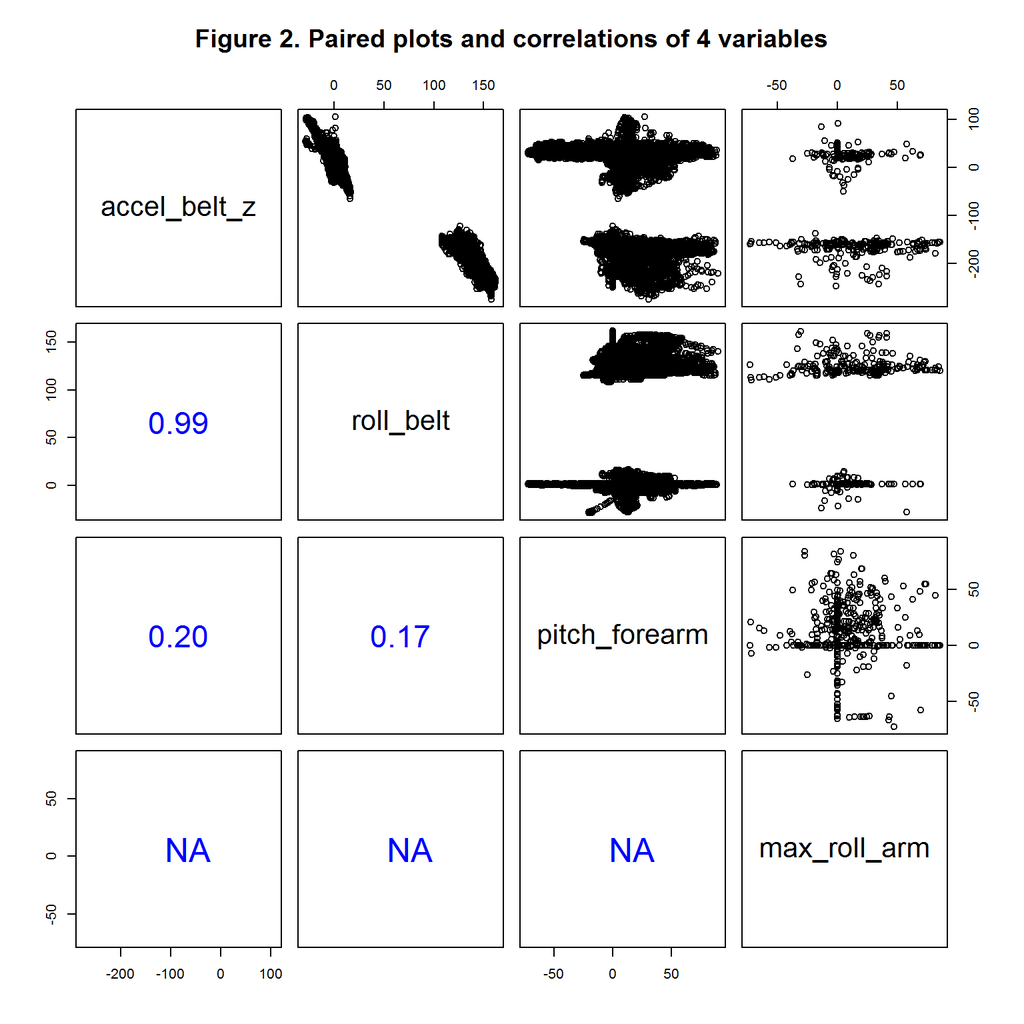

The graphic view of relations between some variables is shown on figure 2. The scatterplots hold pairwise correlations and pairwise plots. Some predictors are highly correlated, like *accel_belt_z* and *roll_belt*. Some features have missing values, like *max_roll_arm*, and correlation cann’t be calculated. Right column of plots confirms that, there are much less points than on the other squares.

### Data preparation

We perform some data preparation steps prior to building our model [2, 3].

We split the *df* set into *training2* and *testing2* sets. This *testing2* set will be used to evaluate performance of a model. We use *createDataPartition* function to create stratified random splits. In this case, 75% of data goes to the new training set and 25% - to the new testing one.

```r
# make training and testing sets
set.seed(1516)
inTrain <- createDataPartition(y = df$classe, p = 0.75, list = FALSE)
training2 <- df[inTrain,]
testing2 <- df[-inTrain,]
```

There are 14718 and 4904 observations of 160 variables in the splits, accordingly.

### Dimension Reduction

The data has one outcome variable *classe* and 159 predictors. Suppose we faced a problem of high dimension. We must perform some techiques and methods to find important variables which have significant effect on outcome and are suitable for model building.

First we use *nearZeroVar* function to remove so-called “near zero-variance predictors” those can not explain the variation in target variable and can cause problems during resampling for some model types. Secondly we look through the data for missing values and remove features with greater than 40% of not available observations. Then remaining predictors are undergo to multicollinearity test. High correlation can lower down the performance of model. We remove variables with correlation greater than 0.9. Also we drop *X* variable as it is just a row number.

```r
# remove near zero variance predictors
nzv <- nearZeroVar(training2)
training2 <- training2[,-nzv]

# remove NA's features
table(summary(training2)[7,])
```

```
##
## (Other)         :8249           NA's   :14415
##                       1                      43
```

```r
columnsNA <- which(grepl("NA's", summary(training2)[7,]))
NAs <- sum(is.na(training2[columnsNA[1]]))
training2 <- training2[,-columnsNA]

# move non-numeric features to the end to to drop correlated features correctly
numVars <- sapply(1:ncol(training2), FUN=function(x) {is.numeric(training2[,x])})
otherVars <- which(!numVars)
numVars <- which(numVars)
training2 <- select(training2, c(numVars, otherVars))

# remove highly correlated features
corrMatrix <- cor(training2[1:length(numVars)])
highCorr <- findCorrelation(corrMatrix, 0.9)
training2 <- training2[,-highCorr]

# remove X feature as it is row number
training2 <- select(training2, -X)
dim(training2)
```

```
## [1] 14718    53
```

There were 43 predictors with missing values. Each of those predictors had 14415 empty values or 98% of total observations. We dropped this variables as they had too little details for our purpose.

Number of predictors dropped because of near zero-variance is 58 and because of high correlation is 5. The reduction steps altogether could shrink the dimension from 159 to 52 features.

## Classification model

### Model building

The *train* function of *caret* package is used to build a model and select its tuning parameters. We choose random forest classification model as widespread and suitable for many applications. There is the only tuning parameter *mtry* which is number of randomly selected predictors as candidates at each split.

Random forest is a default method for *train* function. We change two default parameters of the function: *tuneLength* and resampling method. The first element controls the size of the default grid of tuning parameters. It has 3 as a default value. We set it to 5 to make function research more complexity parameters as candidate values. Default resampling method is bootstrapping. We choose k-fold cross-validation as it works faster and allows to obtain good accuracy. It is necessary to use *trControl* parameter that is a list of control parameters for the *train* function. The function *trainControl* can be used to set *method* parameter as *cv* for k-fold cross-validation. The default number of folds is 10, number of repeats is 1. These values are good in our case and we left them unchanged.

Also we use multiprocessing capabilities of the modern processors to reduce training time. *Parallel* and *doParallel* packages are available to start working with multiple cores. There are some steps to perform: make and register computational cluster, tell *caret* to use this cluster by *allowParallel* parameter of *trainControl* function, fit the model, de-register parallel processing cluster [4].

```r
# train random forest model
cluster <- makeCluster(detectCores() - 1) # convention to leave 1 core for OS
registerDoParallel(cluster)
fitControl <- trainControl(allowParallel = TRUE, method = "cv")
suppressWarnings(suppressMessages(
    fitRF <- train(classe ~ ., data=training2, trControl = fitControl, tuneLength = 5)
))
stopCluster(cluster)
fitRF
```

```
## Random Forest
##
## 14718 samples
##    52 predictor
##     5 classes: 'A', 'B', 'C', 'D', 'E'
##
## No pre-processing
## Resampling: Cross-Validated (10 fold)
## Summary of sample sizes: 13247, 13247, 13245, 13247, 13247, 13245, ...
## Resampling results across tuning parameters:
##
##   mtry  Accuracy   Kappa
##    2    0.9872955  0.9839257
##   20    0.9995923  0.9994844
##   38    0.9996602  0.9995703
##   56    0.9993884  0.9992265
##   74    0.9991845  0.9989686
##
## Accuracy was used to select the optimal model using  the largest value.
## The final value used for the model was mtry = 38.
```

Each row in the table above corresponds to a tuning parameter *mtry*, average *accuracy* and *Kappa* of the 10-fold cross-validation samples. The optimal model is selected as a candidate model with the highest accuracy 99.97%. In the output below, final model parameter *mtry* is 38, estimated error rate is 0.05%.

```r
fitRF$finalModel
```

```
##
## Call:
##  randomForest(x = x, y = y, mtry = param$mtry)
##                Type of random forest: classification
##                      Number of trees: 500
## No. of variables tried at each split: 38
##
##         OOB estimate of  error rate: 0.05%
## Confusion matrix:
##      A    B    C    D    E  class.error
## A 4183    1    0    0    1 0.0004778973
## B    1 2847    0    0    0 0.0003511236
## C    0    1 2566    0    0 0.0003895598
## D    0    0    1 2410    1 0.0008291874
## E    0    0    0    2 2704 0.0007390983
```

We can see which predictors have largest impact on the model.

```r
varImp(fitRF)
```

```
## rf variable importance
##
##   only 20 most important variables shown (out of 74)
##
##                                Overall
## raw_timestamp_part_1           100.000
## num_window                      40.733
## pitch_forearm                   27.284
## magnet_dumbbell_z               18.005
## magnet_belt_y                   17.780
## yaw_belt                        17.587
## pitch_belt                      15.210
## magnet_dumbbell_y               12.257
## cvtd_timestamp02/12/2011 13:33   9.462
## cvtd_timestamp30/11/2011 17:12   8.963
## magnet_dumbbell_x                7.646
## roll_dumbbell                    6.876
## total_accel_belt                 6.793
## roll_forearm                     6.740
## cvtd_timestamp05/12/2011 11:24   6.380
## cvtd_timestamp02/12/2011 14:58   6.281
## cvtd_timestamp28/11/2011 14:15   5.516
## magnet_belt_z                    5.506
## gyros_belt_z                     5.307
## accel_dumbbell_y                 4.953
```

### Model performance

Function *confusionMatrix* is used to describe the performance of classification model on the *testing2* data set. We execute it to calculate a cross-tabulation of real and predicted values of *classe* variable with associated statistics.

```r
(cm <- confusionMatrix(predict(fitRF, newdata = testing2), testing2$classe))
```

```
## Confusion Matrix and Statistics
##
##           Reference
## Prediction    A    B    C    D    E
##          A 1395    1    0    0    0
##          B    0  947    2    0    0
##          C    0    1  853    1    0
##          D    0    0    0  802    0
##          E    0    0    0    1  901
##
## Overall Statistics
##
##                Accuracy : 0.9988
##                  95% CI : (0.9973, 0.9996)
##     No Information Rate : 0.2845
##     P-Value [Acc > NIR] : < 2.2e-16
##
##                   Kappa : 0.9985
##  Mcnemar's Test P-Value : NA
##
## Statistics by Class:
##
##                      Class: A Class: B Class: C Class: D Class: E
## Sensitivity            1.0000   0.9979   0.9977   0.9975   1.0000
## Specificity            0.9997   0.9995   0.9995   1.0000   0.9998
## Pos Pred Value         0.9993   0.9979   0.9977   1.0000   0.9989
## Neg Pred Value         1.0000   0.9995   0.9995   0.9995   1.0000
## Prevalence             0.2845   0.1935   0.1743   0.1639   0.1837
## Detection Rate         0.2845   0.1931   0.1739   0.1635   0.1837
## Detection Prevalence   0.2847   0.1935   0.1743   0.1635   0.1839
## Balanced Accuracy      0.9999   0.9987   0.9986   0.9988   0.9999
```

The accuracy is 99.88%, and error rate is 0.12%. The accuracy is very good, although these values are worse than were estimated above.

### Prediction of new Class

The goal of the work is to predict Class of exercises registered by IMUs. New unindentified Class data are in the data set *mainTest* that was mentioned in the very beginning. The set contains 20 observations. We apply the *fitRF* model to make a decision how well those exercises were performed. Either they match to best Class A or some mistakes drop them into imperfect Classes B,C,D,E.

```r
(pred <- predict(fitRF, newdata = mainTest))
```

```
##  [1] B A B A A E D B A A B C B A E E A B B B
## Levels: A B C D E
```

```r
table(pred)
```

```
## pred
## A B C D E
## 7 8 1 1 3
```

## References

[1] Velloso, E.; Bulling, A.; Gellersen, H.; Ugulino, W.; Fuks, H. Qualitative Activity Recognition of Weight Lifting Exercises. Proceedings of 4th International Conference in Cooperation with SIGCHI (Augmented Human ’13) . Stuttgart, Germany: ACM SIGCHI, 2013. URL http://groupware.les.inf.puc-rio.br/public/papers/2013.Velloso.QAR-WLE.pdf

[2] Kuhn, Max. Building Predictive Models in R Using the caret Package. Journal of Statistical Software. November 2008, Volume 28, Issue 5. URL https://www.jstatsoft.org/index.php/jss/article/view/v028i05/v28i05.pdf

[3] Sunil, Ray. Beginners Guide To Learn Dimension Reduction Techniques. JULY 28, 2015. URL http://www.analyticsvidhya.com/blog/2015/07/dimension-reduction-methods/

[4] Greski, Len. Improving Performance of Random Forest in caret::train(). URL https://github.com/lgreski/datasciencectacontent/blob/master/markdown/pml-randomForestPerformance.md